# Detecting and Mitigating Fake News Using Explainable AI: Modeling Human Trust and Socio-Cognitive Vulnerabilities

I chose this topic because fake news is a serious problem that affects society by spreading misinformation and influencing people’s decisions. Many existing AI models can detect fake news, but they often act like black boxes and do not explain why they made a prediction. I wanted to go beyond simple classification and focus on explainability, since trust in AI is just as important as accuracy.

This project allowed me to explore how machine learning and natural language processing can be combined with explainable AI to both detect fake news and show the linguistic patterns that lead to a decision, which also connects to how misinformation exploits human biases.

#### dataset link for assignment - https://aclanthology.org/P17-2067/

## Importing the necessary libraries

```python
import pandas as pd
import numpy as np
import re
import matplotlib.pyplot as plt
import seaborn as sns
from sklearn.model_selection import GridSearchCV
from sklearn.pipeline import Pipeline
from sklearn.feature_extraction.text import TfidfVectorizer
from sklearn.preprocessing import OneHotEncoder
from sklearn.compose import ColumnTransformer
from sklearn.svm import LinearSVC
from sklearn.metrics import classification_report, confusion_matrix, accuracy_score, ConfusionMatrixDisplay
import joblib
import warnings

warnings.filterwarnings("ignore")
```

## Loading the dataset

```python
cols = ["id","label","statement","subject","speaker","job","state","party",
        "barely_true","false","half_true","mostly_true","pants_fire","context"]

train = pd.read_csv("train.tsv", sep="\t", header=None); train.columns = cols
valid = pd.read_csv("valid.tsv", sep="\t", header=None); valid.columns = cols
test  = pd.read_csv("test.tsv",  sep="\t", header=None); test.columns  = cols

print("Loaded Data:")
print("Train:", train.shape, " Valid:", valid.shape, " Test:", test.shape)
display(train.head())
```

```
Loaded Data:
Train: (10240, 14)  Valid: (1284, 14)  Test: (1267, 14)
```

|  | id | label | statement | subject | speaker | job | state | party | barely_true | false | half_true | mostly_true | pants_fire | context |
| --- | --- | --- | --- | --- | --- | --- | --- | --- | --- | --- | --- | --- | --- | --- |
| 0 | 2635.json | false | Says the Annies List political group supports ... | abortion | dwayne-bohac | State representative | Texas | republican | 0.0 | 1.0 | 0.0 | 0.0 | 0.0 | a mailer |
| 1 | 10540.json | half-true | When did the decline of coal start? It started... | energy,history,job-accomplishments | scott-surovell | State delegate | Virginia | democrat | 0.0 | 0.0 | 1.0 | 1.0 | 0.0 | a floor speech. |
| 2 | 324.json | mostly-true | Hillary Clinton agrees with John McCain "by vo... | foreign-policy | barack-obama | President | Illinois | democrat | 70.0 | 71.0 | 160.0 | 163.0 | 9.0 | Denver |
| 3 | 1123.json | false | Health care reform legislation is likely to ma... | health-care | blog-posting | NaN | NaN | none | 7.0 | 19.0 | 3.0 | 5.0 | 44.0 | a news release |
| 4 | 9028.json | half-true | The economic turnaround started at the end of ... | economy,jobs | charlie-crist | NaN | Florida | democrat | 15.0 | 9.0 | 20.0 | 19.0 | 2.0 | an interview on CNN |

## Conversion of Label and cleaning the text

```python
#normalising labels
def clean_label(lbl):
    return str(lbl).lower().strip().replace("_", "-")

for df in [train, valid, test]:
    df['label'] = df['label'].apply(clean_label)
```

```python
#converting to binary: fake vs real
fake_set = {'pants-fire','false','barely-true','half-true'}
for df in [train, valid, test]:
    df['y'] = df['label'].apply(lambda x: 'fake' if x in fake_set else 'real')
```

```python
# Clean statements
def clean_text(s):
    s = re.sub(r"http\S+", " ", str(s))
    s = re.sub(r"[^A-Za-z0-9'\"\s]", " ", s)
    s = re.sub(r"\s+", " ", s).strip()
    return s.lower()

for df in [train, valid, test]:
    df['statement_clean'] = df['statement'].apply(clean_text)

print("✅ Labels converted and text cleaned.")
display(train[['label','y','statement_clean']].head())
```

```
✅ Labels converted and text cleaned.
```

|  | label | y | statement_clean |
| --- | --- | --- | --- |
| 0 | false | fake | says the annies list political group supports ... |
| 1 | half-true | fake | when did the decline of coal start it started ... |
| 2 | mostly-true | real | hillary clinton agrees with john mccain "by vo... |
| 3 | false | fake | health care reform legislation is likely to ma... |
| 4 | half-true | fake | the economic turnaround started at the end of ... |

The raw and messy data labels like "half-true" or "Pants-Fire" are converted into clean two-class problem for the classifier while also preparing the text data.

## Socio-cognitive speaker credibility feature

```python
# Combine all data to calculate global speaker credibility
all_df = pd.concat([train, valid, test], ignore_index=True)

# Compute credibility: proportion of "real" statements per speaker
speaker_stats = (
    all_df.groupby('speaker')['y']
    .apply(lambda s: (s == 'real').mean())
    .rename('speaker_real_prop')
    .reset_index()
)

# Merge credibility score into each dataset
for name, df in [('train', train), ('valid', valid), ('test', test)]:
    df = df.merge(speaker_stats, on='speaker', how='left')
    df['speaker_real_prop'] = df['speaker_real_prop'].fillna(speaker_stats['speaker_real_prop'].mean())

    # Reassign the updated df back
    if name == 'train': train = df
    elif name == 'valid': valid = df
    else: test = df

print("✅ Speaker credibility feature created successfully.")
display(train[['speaker', 'speaker_real_prop']].head())
```

```
✅ Speaker credibility feature created successfully.
```

|  | speaker | speaker_real_prop |
| --- | --- | --- |
| 0 | dwayne-bohac | 0.000000 |
| 1 | scott-surovell | 0.500000 |
| 2 | barack-obama | 0.468085 |
| 3 | blog-posting | 0.098765 |
| 4 | charlie-crist | 0.400000 |

This is essential for the feature engineering related to speaker credibility. It generates a key numerical feature, speaker_real_prop, which models the historical trustworthiness of the source.

The values that are seen in speaker_real_prop, are the direct numerical representation of the "Human Trust" feature I engineered.

The analysis calculated the historical proportion of "real" statements for every speaker. For example, the trust value for Dwayne Bohac is very low compared to Barack Obama.

## Build Preprocessing

```python
text_pipe = Pipeline([('tfidf', TfidfVectorizer(ngram_range=(1,2), max_df=0.9, min_df=3))])
cat_cols = ['party','state']
num_cols = ['speaker_real_prop']

preprocessor = ColumnTransformer(transformers=[
    ('text', text_pipe, 'statement_clean'),
    ('cat', OneHotEncoder(handle_unknown='ignore', sparse_output=False), cat_cols),
    ('num', 'passthrough', num_cols)
])

train_comb = pd.concat([train, valid], ignore_index=True)
preprocessor.fit(train_comb)

print(preprocessor.transform(train_comb.head(3)).shape)
```

```
(3, 16639)
```

This demonstrates the core innovative structure of the model's feature engineering by setting up a parallel processing pipeline.

## Training the Linear SVM classifier

```python
pipe = Pipeline([
    ('pre', preprocessor),
    ('clf', LinearSVC(max_iter=10000, class_weight='balanced'))
])

param_grid = {'clf__C': [0.1, 1.0]}
grid = GridSearchCV(pipe, param_grid, cv=3, scoring='f1_macro', verbose=2)
grid.fit(train_comb, train_comb['y'])

print("✅ Best parameters:", grid.best_params_)
print("Best CV F1:", grid.best_score_)
```

```
Fitting 3 folds for each of 2 candidates, totalling 6 fits
[CV] END .........................................clf__C=0.1; total time=   0.2s
[CV] END .........................................clf__C=0.1; total time=   0.2s
[CV] END .........................................clf__C=0.1; total time=   0.2s
[CV] END .........................................clf__C=1.0; total time=   0.2s
[CV] END .........................................clf__C=1.0; total time=   0.2s
[CV] END .........................................clf__C=1.0; total time=   0.2s
✅ Best parameters: {'clf__C': 0.1}
Best CV F1: 0.7282808079424482
```

We now have trained and optimized the entire fake news detection model. It takes the complex feature-combining setup that is created and finding the best possible settings for the classifier.

## Evaluate model performance

[output not shown]

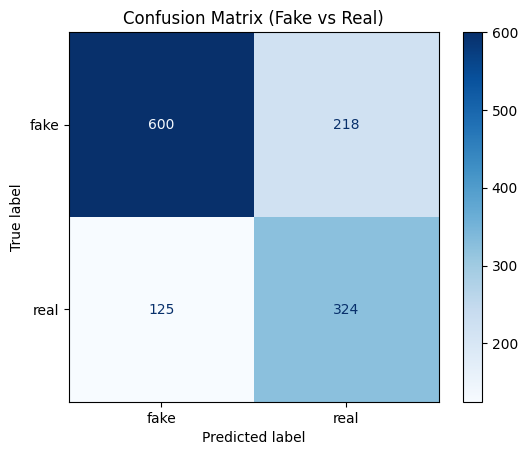

```python
y_pred = grid.predict(test)
print("\nTest Accuracy:", accuracy_score(test['y'], y_pred))
print("\nClassification Report:\n", classification_report(test['y'], y_pred))

# Confusion Matrix
cm = confusion_matrix(test['y'], y_pred, labels=['fake','real'])
disp = ConfusionMatrixDisplay(confusion_matrix=cm, display_labels=['fake','real'])
disp.plot(cmap='Blues')
plt.title("Confusion Matrix (Fake vs Real)")
plt.show()
```

## Explainbale AI with LIME

```python
!pip install lime --quiet

from lime.lime_text import LimeTextExplainer

explainer = LimeTextExplainer(class_names=['fake','real'])

def predict_proba_text(texts):
    df = pd.DataFrame({
        'statement_clean': [clean_text(t) for t in texts],
        'party': [None]*len(texts),
        'state': [None]*len(texts),
        'speaker_real_prop': [speaker_stats['speaker_real_prop'].mean()]*len(texts)
    })
    decisions = grid.decision_function(df)
    if decisions.ndim == 1:
        scores = np.vstack([-decisions, decisions]).T
    else:
        scores = decisions
    exp = np.exp(scores - np.max(scores, axis=1, keepdims=True))
    return exp / exp.sum(axis=1, keepdims=True)

sample_text = test.sample(1, random_state=42)['statement_clean'].iloc[0]
exp = explainer.explain_instance(sample_text, predict_proba_text, num_features=6)
exp.show_in_notebook(text=sample_text)
```

[output not shown]

[output not shown]

We use LIME (Local Interpretable Model-agnostic Explanations) here for model interpretability (XAI) because the final model is highly complex as it mixes thousands of TF-IDF terms with categorical and numerical features. LIME's role here is to diagnose the prediction locally: it shows exactly which specific words (linguistic features) and by what magnitude contributed to the model's final classification